# Mask-usage recognition with Machine learning.

**Introduction**

The following exercise has the purpose of using Machine Learning to identify the usage of masks in different images of people.

With the ongoing situation of the Covid pandemic the usage of masks took an important role in the fight against the transmission of the virus. Using the World’s Health Organization words:

> ‘Masks are a key measure to suppress transmission and save lives’.<sup>1</sup>

The idea is to use a machine learning library and model to identify if a person is wearing or not a mask; exploring the capabilities of machine learning.

For this exercise I used TensorFlow, the open-source library for machine learning; and the datasets used for training and testing were taken from Kaggle.<sup>2</sup> Without further due, let’s jump right in to the exercise.

**Imports.**

The first thing to do is to import all the necessary libraries.

```python
import tensorflow as tf
import matplotlib.pyplot as plt
import numpy as np
import os, sys

from tensorflow import keras
from tensorflow.keras import layers
from tensorflow.keras.models import Sequential
```

**Preprocessing.**

To be able to feed the model with data, it has to be preprocessed first. This means that the data has to be in the right format; in this case the data will transformed from an image to a tensor so the model can read and work with it.

```python
dataset= tf.keras.preprocessing.image_dataset_from_directory(
    "Your directory path for the data files goes here", labels='inferred', label_mode='int',
    class_names=None, color_mode='rgb', batch_size=32, image_size=(128,
    128), shuffle=True, validation_split=.3, subset='training',
    interpolation='bilinear'
)
```

```
Found 7031 files belonging to 3 classes.
Using 4922 files for training.
```

```python
valdata = tf.keras.preprocessing.image_dataset_from_directory(
    "Your directory path for the data files goes here",labels='inferred', label_mode='int',
    class_names=None, color_mode='rgb', batch_size=32, image_size=(128,
    128), shuffle=True, validation_split=.3, subset='validation',
    interpolation='bilinear'
)
```

```
Found 7031 files belonging to 3 classes.
Using 2109 files for validation.
```

The data is divided in two: a training set which will be used to train the model, and a validation set for a preliminary estimation of the performance, so the process of training can adjust the parameters.

Each one of the datasets will be also divided in batches, with the following shape:

```python
dataset
```

```
<BatchDataset shapes: ((None, 128, 128, 3), (None,)), types: (tf.float32, tf.int32)>
```

The model will be trained to identify 3 categories: mask used incorrectly, mask and no mask, with their respective labels as follows:

```python
class_names = dataset.class_names
print(class_names)
```

```
['incorrectly', 'mask', 'nomask']
```

**Examples of images**

Let’s see some examples of the images that will go into the model (It’s important to remember that the model will not work with the original format of the images, that’s why they are “preprocessed” first)

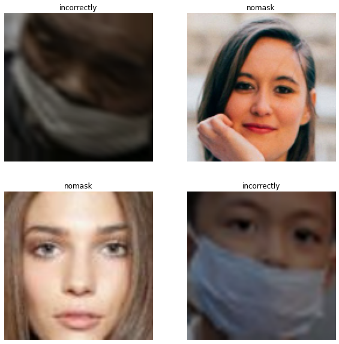

```python
plt.figure(figsize=(10, 10))
for images, labels in dataset.take(1):
  for i in range(4):
    ax = plt.subplot(2, 2, i + 1)

    plt.imshow(images[i].numpy().astype("uint8"))
    plt.title(class_names[labels[i]])
    plt.axis("off")
```

The following code execution shows the shape of a batch in the training dataset. It is easy to see that each batch consists of 32 images or samples.

```python
for image_batch, labels_batch in dataset:
  print(image_batch.shape)
  print(labels_batch.shape)
  break
```

```
(32, 128, 128, 3)
(32,)
```

## Build the model

> “[It] is the simple application of a filter to an input that results in an activation. Repeated application of the same filter to an input results in a map of activations called a feature map, indicating the locations and strength of a detected feature in an input, such as an image. <sup>3</sup>

```python
num_classes = 3

model = Sequential([
  layers.experimental.preprocessing.Rescaling(1./255, input_shape=(128, 128, 3)),
  layers.Conv2D(16, 3, padding='same', activation='relu'),
  layers.MaxPooling2D(),
  layers.Conv2D(32, 3, padding='same', activation='relu'),
  layers.MaxPooling2D(),
  layers.Conv2D(64, 3, padding='same', activation='relu'),
  layers.MaxPooling2D(),
  layers.Flatten(),
  layers.Dense(128, activation='relu'),
  layers.Dense(num_classes)
])
```

**Compile the model**

After we build the model it’s necessary to compile and select the hyperparameters (optimizers and loss function) that will guide and adjust the model to be able to ‘learn’ from the training set.

```python
model.compile(optimizer='adam',
              loss=tf.keras.losses.SparseCategoricalCrossentropy(from_logits=True),
              metrics=['accuracy'])
```

To see how the model looks once it’s built, the summary method is called:

```python
model.summary()
```

```
Model: "sequential"
_________________________________________________________________
Layer (type)                 Output Shape              Param #
=================================================================
rescaling (Rescaling)        (None, 128, 128, 3)       0
_________________________________________________________________
conv2d (Conv2D)              (None, 128, 128, 16)      448
_________________________________________________________________
max_pooling2d (MaxPooling2D) (None, 64, 64, 16)        0
_________________________________________________________________
conv2d_1 (Conv2D)            (None, 64, 64, 32)        4640
_________________________________________________________________
max_pooling2d_1 (MaxPooling2 (None, 32, 32, 32)        0
_________________________________________________________________
conv2d_2 (Conv2D)            (None, 32, 32, 64)        18496
_________________________________________________________________
max_pooling2d_2 (MaxPooling2 (None, 16, 16, 64)        0
_________________________________________________________________
flatten (Flatten)            (None, 16384)             0
_________________________________________________________________
dense (Dense)                (None, 128)               2097280
_________________________________________________________________
dense_1 (Dense)              (None, 3)                 387
=================================================================
Total params: 2,121,251
Trainable params: 2,121,251
Non-trainable params: 0
_________________________________________________________________
```

**Training the model**

```python
epochs=10
history = model.fit(
  dataset,
  validation_data=valdata,
  epochs=epochs
)
```

We can have a reference on how the model is performing during each epoch of training thanks to the validation set which can compared with the training set. The performance is measured with two metrics: accuracy and the result of the loss function for each epoch.

Seeing the accuracy results it appears that the model is not overfitted (yet) as it provided a high accuracy for the validation data set. It is also possible to note that with every epoch the accuracy increases in the training dataset. This means the training is capable of adjusting its parameters for learning better. However it could also mean that the adjustment could be adapting to the samples too much.

Regarding the results of the loss function for the training set and the validation set, it also seems to be a good result. The loss function decreases drastically in the first epochs, which shows the model is reducing the difference between the prediction and the actual result. However it is also showing signs of overfitting; the loss function keeps drecreasing for the training samples, but for the validation samples it has spikes showing a higher loss function, which means the parameters are adjusting mainly for the training samples.

Nevertheless it is still important to see the model perform in new data (the test dataset)

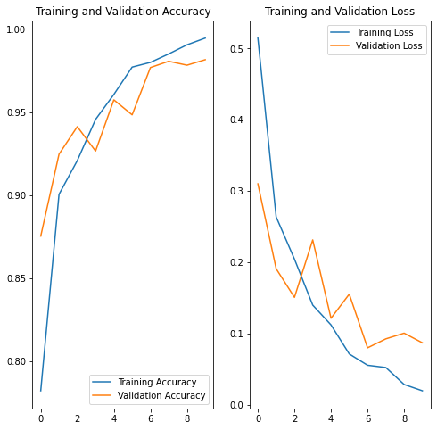

```python
acc = history.history['accuracy']
val_acc = history.history['val_accuracy']

loss = history.history['loss']
val_loss = history.history['val_loss']

epochs_range = range(epochs)

plt.figure(figsize=(8, 8))
plt.subplot(1, 2, 1)
plt.plot(epochs_range, acc, label='Training Accuracy')
plt.plot(epochs_range, val_acc, label='Validation Accuracy')
plt.legend(loc='lower right')
plt.title('Training and Validation Accuracy')

plt.subplot(1, 2, 2)
plt.plot(epochs_range, loss, label='Training Loss')
plt.plot(epochs_range, val_loss, label='Validation Loss')
plt.legend(loc='upper right')
plt.title('Training and Validation Loss')
plt.show()
```

It’s important to note that the model has not suffered major or minor changes from its initial setting. Definitely the power of keras, Tensorflow and machine learning in general can be seen here; without further tuning, it seems the model does a pretty good job classifying images of people wearing masks, wearing them incorrectly or not wearing them at all.

## Testing the model.

Once the model is built and has been trained, it's time to put it to the test.

**Preprocessing for the test dataset**

To preprocess the test dataset the steps are the same as with the training dataset.

```python
testdata = tf.keras.utils.image_dataset_from_directory(
    "Your directory path for the data files goes here", labels='inferred', label_mode='int',
    class_names=None, color_mode='rgb',  image_size=(128,
    128), shuffle=True
)
```

```
Found 2073 files belonging to 3 classes.
```

```python
testdata
```

```
<BatchDataset shapes: ((None, 128, 128, 3), (None,)), types: (tf.float32, tf.int32)>
```

```python
for image_batch, labels_batch in testdata:
  print(image_batch.shape)
  print(labels_batch.shape)
  break
```

```
(32, 128, 128, 3)
(32,)
```

```python
class_names2 = testdata.class_names
class_names
```

```
['incorrectly', 'mask', 'nomask']
```

## Testing the model with new data

One way to see how the model performs on new data (data that was not used for training nor validation) is by simply calling the *evaluate* method on the test dataset. This method measures the loss function and the accuracy of all the samples in the test dataset, giving a good reference of how is the model performing

```python
test_loss, test_acc = model.evaluate(testdata)
```

[output not shown]

The model predicted correctly 92.52% of the samples.

The performance wasn't as good as the one with the training or validation samples, which means overfitting. Nonetheless the model still has a high accuracy, making it useful for prediction.

## Exploring results.

Despite the model evaluation provided a good result, it is also a good idea to see it in action next to the actual images that are used for prediction.

```
The first image most likely belongs to mask with a 100.00 percent confidence.
The second image most likely belongs to nomask with a 100.00 percent confidence.
The third image most likely belongs to mask with a 100.00 percent confidence.
The fourth image most likely belongs to nomask with a 91.85 percent confidence.
```

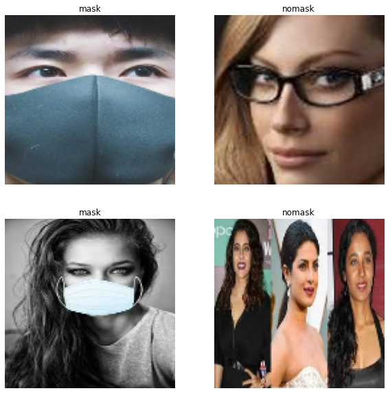

```python
num_image= ["first image", "second image", "third image", "fourth image"]

plt.figure(figsize=(10, 10))
for images, labels in testdata.take(1):
  for i in range(4):
    ax = plt.subplot(2, 2, i + 1)

    plt.imshow(images[i].numpy().astype("uint8"))
    plt.title(class_names2[labels[i]])
    plt.axis("off")

    img_array = keras.preprocessing.image.img_to_array(images[i])
    img_array = tf.expand_dims(img_array, 0) # Create a batch

    predictions = model.predict(img_array)
    score = tf.nn.softmax(predictions[0])
    print(
    "The {} most likely belongs to {} with a {:.2f} percent confidence."
    .format(num_image[i], class_names[np.argmax(score)], 100 * np.max(score)))
```

The model predicts correctly the previous four images. It also provided a percentage of confidence about the category for the image.

Below there are more examples.

```
The first image most likely belongs to nomask with a 92.67 percent confidence.
The second image most likely belongs to mask with a 100.00 percent confidence.
The third image most likely belongs to mask with a 99.99 percent confidence.
The fourth image most likely belongs to incorrectly with a 99.98 percent confidence.
```

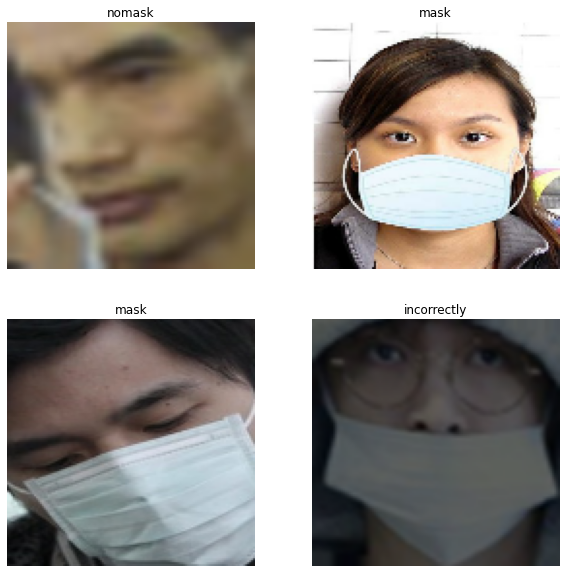

```python
num_image= ["first image", "second image", "third image", "fourth image"]

plt.figure(figsize=(10, 10))
for images, labels in testdata.take(1):
  for i in range(4):
    ax = plt.subplot(2, 2, i + 1)

    plt.imshow(images[i].numpy().astype("uint8"))
    plt.title(class_names2[labels[i]])
    plt.axis("off")

    img_array = keras.preprocessing.image.img_to_array(images[i])
    img_array = tf.expand_dims(img_array, 0) # Create a batch

    predictions = model.predict(img_array)
    score = tf.nn.softmax(predictions[0])
    print(
    "The {} most likely belongs to {} with a {:.2f} percent confidence."
    .format(num_image[i], class_names[np.argmax(score)], 100 * np.max(score)))
```

```
The first image most likely belongs to mask with a 100.00 percent confidence.
The second image most likely belongs to nomask with a 100.00 percent confidence.
The third image most likely belongs to nomask with a 100.00 percent confidence.
The fourth image most likely belongs to nomask with a 100.00 percent confidence.
The fifth image most likely belongs to mask with a 68.22 percent confidence.
The sixth image most likely belongs to mask with a 100.00 percent confidence.
```

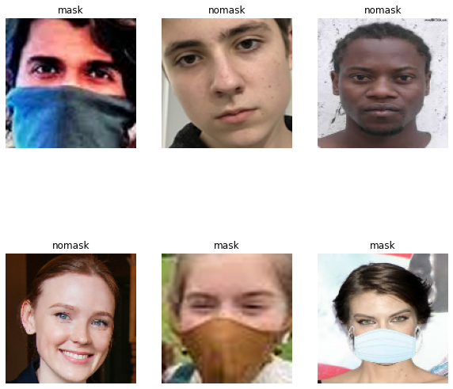

```python
num_image= ["first image", "second image", "third image", "fourth image", "fifth image", "sixth image"]

plt.figure(figsize=(10, 10))
for images, labels in testdata.take(1):
  for i in range(6):
    ax = plt.subplot(2, 3, i + 1)

    plt.imshow(images[i].numpy().astype("uint8"))
    plt.title(class_names2[labels[i]])
    plt.axis("off")

    img_array = keras.preprocessing.image.img_to_array(images[i])
    img_array = tf.expand_dims(img_array, 0) # Create a batch

    predictions = model.predict(img_array)
    score = tf.nn.softmax(predictions[0])
    print(
    "The {} most likely belongs to {} with a {:.2f} percent confidence."
    .format(num_image[i], class_names[np.argmax(score)], 100 * np.max(score)))
```

## Conclusion

This was a simple exercise to explore machine learning and Tensorflow capabilities. It was possible to see that convolutional networks are a great option for image classification; In this exercise a basic convolutional model was built with an accuracy over 90% classifying images into three categories. Not only the ideas and theory behind Machine learning are effective but also the tools to apply those ideas are powerful enough to find useful and interesting applications. Definitely in a production environment more aspects should be considered, but the foundation for the use of data and machine learning is set and ready to be exploited.

## References

**1.** https://www.who.int/emergencies/diseases/novel-coronavirus-2019/question-and-answers-hub/q-a-detail/coronavirus-disease-covid-19-masks

**2.**https://www.kaggle.com/prithwirajmitra/covid-face-mask-detection-dataset https://www.kaggle.com/vijaykumar1799/face-mask-detection https://www.kaggle.com/spandanpatnaik09/face-mask-detectormask-not-mask-incorrect-mask

**3.**https://machinelearningmastery.com/convolutional-layers-for-deep-learning-neural-networks/